# 2.1: Checking species parameterisation for `atlantic_salmon`

FAO Climate Change Risks to Fed Mariculture

Author

Tormey Reimer

Published

1 April 2026

← Previous: Choosing species →

Next: TBD →

# Overview

These documents runs a quick sanity check on each parameterised species. For each model, we:

1. Generate a default one-year sinusoidal temperature time-series centred on the species’ optimal feeding temperature.
2. Load the species-specific bioenergetic parameters from `data/raw_data/parameters_species.xlsx`.
3. Simulate growth of a single representative individual using `fish_growth()`.
4. Plot all output variables as line graphs facetted by output measure to confirm that the model is behaving sensibly.

Default feed parameters are used throughout (a generic whole-feed composition with reasonable digestibilities) since the purpose here is to check that the bioenergetic parameters produce plausible growth trajectories, not to evaluate any particular feed formulation.

# Species parameters

**Load species parameters for atlantic_salmon**

```r
this_species <- "atlantic_salmon"

parameters_species <- read_excel(
  file.path(rawdata_path, 'parameters_species.xlsx'),
  sheet = this_species,
  trim_ws = T,
  n_max = 28
) %>%
  clean_names() %>%
  select(used_in_script, description, value, unit, reference)
```

**Load species parameters for atlantic_salmon**

```r
species_params <- parameters_species %>% pull(value) %>% as.numeric()
names(species_params) <- parameters_species %>% pull(used_in_script)

species_params[["overFmean"]] <- 0.025
species_params[["overFdelta"]] <- 0.0025
```

Each section below runs the sanity check for one species. The temperature time-series is centred on the species’ optimal feeding temperature ($T_{oa}$). Plots show all 30 model output variables facetted by measure; the last row (harvest day) has NA values for all variables except weight, which is expected.

**Define default feed parameters and simulation times used**

```r
feed_params <- list(
  Proteins =      list(proportion = 1, macro = 0.35,  digest = 0.85),
  Lipids =        list(proportion = 1, macro = 0.368, digest = 0.95),
  Carbohydrates = list(proportion = 1, macro = 0.22,  digest = 0.76)
)

times_default <- c(
  t_start = 1L,
  t_end   = species_params[["gd"]],
  dt      = 1L
)
```

**Generate a generic temperature time-series**

```r
mean <- species_params['Toa']
amp <- (species_params['Tma'] - species_params['Toa']) * 0.35

# Centre temperature on species optimal feeding temperature
water_temp <- mean + amp * sin(seq(0, 2 * pi, length.out = 365))

water_temp <- data.frame(
  day = 1:730L,
  temp_C = c(water_temp, water_temp)
) %>%
  filter(day <= species_params[["gd"]])
```

**Plot temperature time-series with thermal limits**

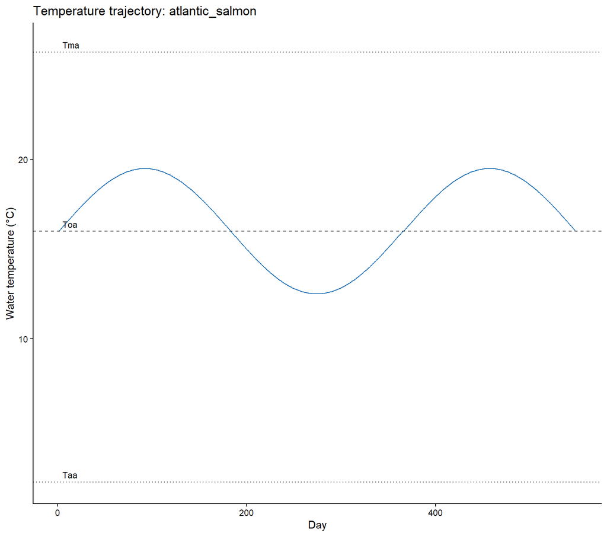

Figure 1: Default sinusoidal water temperature trajectory, with dashed lines showing minimum (Taa), optimal (Toa) and maximum (Tma) feeding temperatures.

```r
water_temp %>%
  ggplot(aes(day, temp_C)) +
  geom_line(colour = '#2171b5') +
  geom_hline(
    yintercept = c(
      species_params['Taa'],
      species_params['Toa'],
      species_params['Tma']
    ),
    linetype = c('dotted', 'dashed', 'dotted'),
    alpha    = 0.7
  ) +
  annotate('text', x = 5, y = species_params['Taa'] + 0.4, label = 'Taa', hjust = 0, size = 3) +
  annotate('text', x = 5, y = species_params['Toa'] + 0.4, label = 'Toa', hjust = 0, size = 3) +
  annotate('text', x = 5, y = species_params['Tma'] + 0.4, label = 'Tma', hjust = 0, size = 3) +
  labs(x = 'Day', y = 'Water temperature (°C)',
       title = sprintf('Temperature trajectory: %s', this_species)) +
  theme_classic()
```

```r
check_fish_growth_inputs(
  species_params = species_params,
  water_temp     = water_temp$temp_C,
  feed_params    = feed_params,
  times          = c(
    "t_start" = min(water_temp$day),
    "t_end" = max(water_temp$day),
    "dt" = 1
  ),
  init_weight    = species_params['meanW'],
  ingmax         = species_params['meanImax']
)
```

```
All inputs look good — `fish_growth()` should run without errors.
```

**Run fish_growth() for a representative individual**

```r
set.seed(42)
one_fish <- fish_growth(
  species_params = species_params,
  water_temp     = water_temp$temp_C,
  feed_params    = feed_params,
  times          = c(
    "t_start" = min(water_temp$day),
    "t_end" = max(water_temp$day),
    "dt" = 1
  ),
  init_weight    = species_params['meanW'],
  ingmax         = species_params['meanImax']
)

cat(sprintf(
  'Initial weight: %.1f g  |  Final weight: %.1f g  |  Approx. FCR: %.2f \n',
  one_fish[1, 'weight'],
  tail(one_fish[, 'weight'], 1),
  sum(one_fish[, 'food_prov'], na.rm = T) / (tail(one_fish[, 'weight'], 1) - one_fish[1, 'weight'])
))
```

```
Initial weight: 125.0 g  |  Final weight: 4058.0 g  |  Approx. FCR: 1.23
```

# Quick checks

**Plot all fish_growth() outputs facetted by measure**

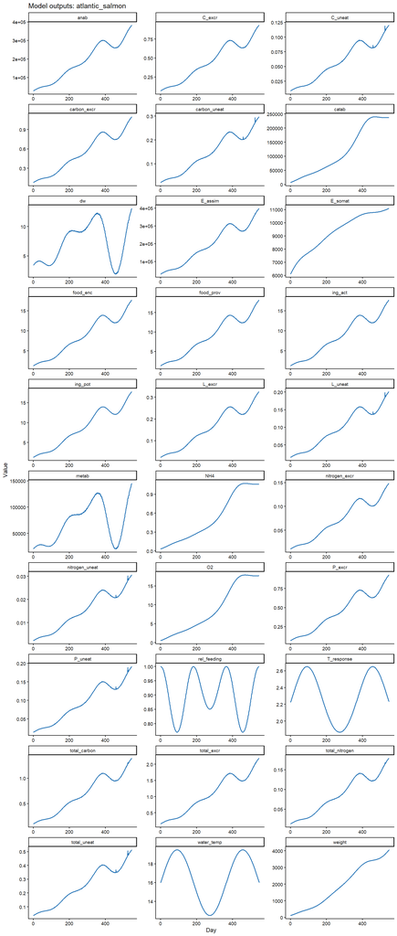

Figure 2: All fish_growth() output variables for a representative individual over a single grow-out period using the default temperature trajectory and feed composition.

```r
as.data.frame(one_fish) %>%
  pivot_longer(
    cols      = !contains('days'),
    names_to  = 'output_var',
    values_to = 'value'
  ) %>%
  ggplot(aes(days, value)) +
  geom_line(colour = '#2171b5', linewidth = 0.6, na.rm = TRUE) +
  facet_wrap(~output_var, scales = 'free', ncol = 3) +
  labs(
    x     = 'Day',
    y     = 'Value',
    title = sprintf('Model outputs: %s', this_species)
  ) +
  theme_classic(base_size = 9) +
  theme(strip.text = element_text(size = 7))
```

## Harvest weight

**Extract modelled harvest weight**

```r
harvest_wt_g  <- tail(one_fish[, "weight"], 1)
harvest_wt_kg <- harvest_wt_g / 1000

cat(sprintf("Modelled harvest weight: %.1f g  (%.2f kg)\n", harvest_wt_g, harvest_wt_kg))
```

```
Modelled harvest weight: 4058.0 g  (4.06 kg)
```

Replace the placeholder rows below with values from the literature or on-farm data. Each row needs a short label (`source`) and a harvest weight in **kg**.

**Compare modelled harvest weight against observed data**

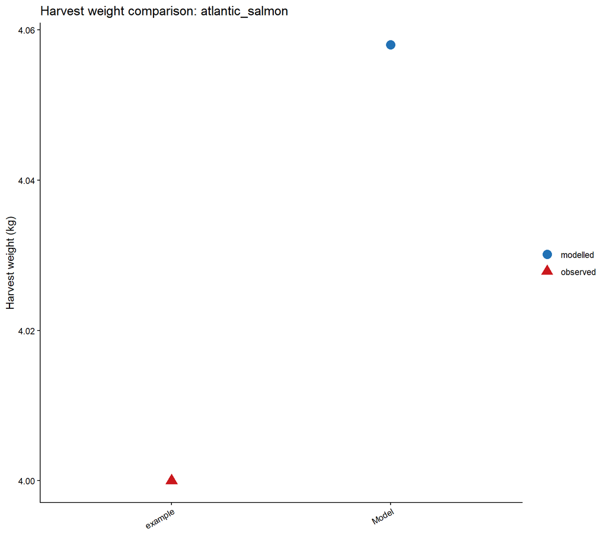

```r
# ── ADD OBSERVED DATA HERE ───────────────────────────────────────────────────
# Add one row per data point; set weight_kg to the observed harvest weight.
observed_harvest_wt <- tribble(
  ~source,               ~weight_kg,
  "example",             4
  # "Author et al. YYYY",  0.0,      # ← replace with real values
)
# ─────────────────────────────────────────────────────────────────────────────

comparison_harvest_wt <- bind_rows(
  tibble(source = "Model", weight_kg = harvest_wt_kg, type = "modelled"),
  mutate(observed_harvest_wt, type = "observed")
)

if (nrow(observed_harvest_wt) > 0) {
  comparison_harvest_wt %>%
    ggplot(aes(x = source, y = weight_kg, colour = type, shape = type)) +
    geom_point(size = 4) +
    scale_colour_manual(values = c(modelled = "#2171b5", observed = "#cb181d")) +
    labs(
      x      = NULL,
      y      = "Harvest weight (kg)",
      colour = NULL, shape = NULL,
      title  = sprintf("Harvest weight comparison: %s", this_species)
    ) +
    theme_classic() +
    theme(axis.text.x = element_text(angle = 30, hjust = 1))
} else {
  message("No observed harvest-weight data provided — add rows to `observed_harvest_wt` to enable comparison.")
  knitr::kable(
    tibble(source = "Model", weight_kg = round(harvest_wt_kg, 2)),
    caption = "Modelled harvest weight (kg)"
  )
}
```

## Feed conversion ratio (FCR)

FCR here is the whole-cycle ratio of total feed provided to net weight gain (live-weight basis).

**Calculate modelled FCR**

```r
total_feed_g  <- sum(one_fish[, "food_prov"], na.rm = TRUE)
weight_gain_g <- tail(one_fish[, "weight"], 1) - one_fish[1, "weight"]
fcr_modelled  <- total_feed_g / weight_gain_g

cat(sprintf(
  "Total feed provided: %.1f g  |  Weight gain: %.1f g  |  FCR: %.3f\n",
  total_feed_g, weight_gain_g, fcr_modelled
))
```

```
Total feed provided: 4854.1 g  |  Weight gain: 3933.0 g  |  FCR: 1.234
```

Add observed FCR values below. FCR is dimensionless (g feed g⁻¹ gain).

**Compare modelled FCR against observed data**

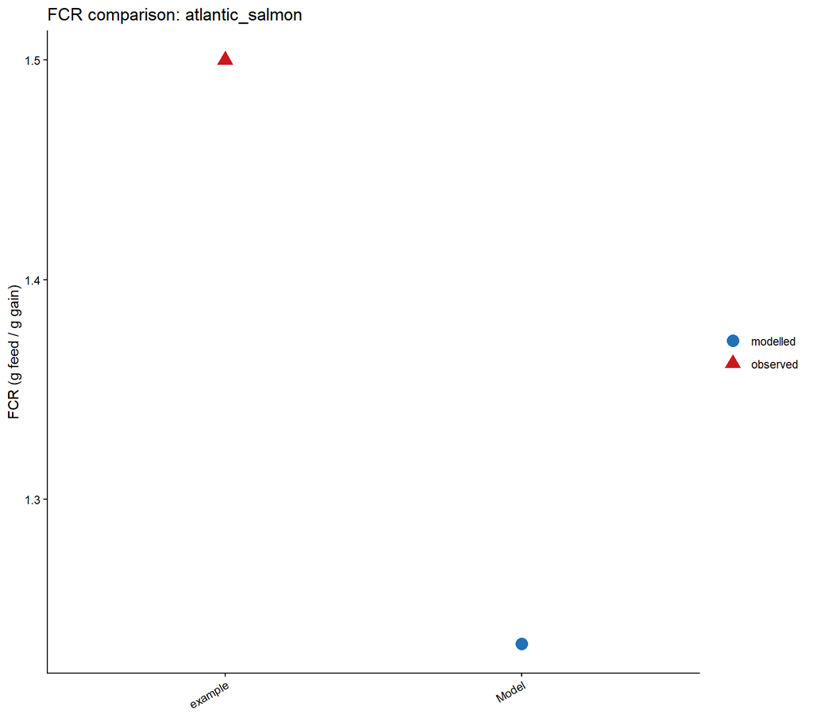

```r
# ── ADD OBSERVED DATA HERE ───────────────────────────────────────────────────
observed_fcr <- tribble(
  ~source,               ~fcr,
  "example",             1.5
  # "Author et al. YYYY",  0.0,      # ← replace with real values
)
# ─────────────────────────────────────────────────────────────────────────────

comparison_fcr <- bind_rows(
  tibble(source = "Model", fcr = fcr_modelled, type = "modelled"),
  mutate(observed_fcr, type = "observed")
)

if (nrow(observed_fcr) > 0) {
  comparison_fcr %>%
    ggplot(aes(x = source, y = fcr, colour = type, shape = type)) +
    geom_point(size = 4) +
    scale_colour_manual(values = c(modelled = "#2171b5", observed = "#cb181d")) +
    labs(
      x      = NULL,
      y      = "FCR (g feed / g gain)",
      colour = NULL, shape = NULL,
      title  = sprintf("FCR comparison: %s", this_species)
    ) +
    theme_classic() +
    theme(axis.text.x = element_text(angle = 30, hjust = 1))
} else {
  message("No observed FCR data provided — add rows to `observed_fcr` to enable comparison.")
  knitr::kable(
    tibble(source = "Model", FCR = round(fcr_modelled, 3)),
    caption = "Modelled FCR"
  )
}
```

## Specific growth rate (SGR)

Two SGR values are reported: the **cycle-averaged SGR** (computed from initial and final weights over the full grow-out), and the **time series of daily SGR** across the grow-out. Observed values in the literature are most commonly reported as cycle averages, so that is the primary comparison target.

**Calculate modelled SGR (cycle average and daily)**

```r
n_days       <- nrow(one_fish) - 1L          # number of growth intervals
w_init       <- one_fish[1, "weight"]
w_final      <- tail(one_fish[, "weight"], 1)

sgr_avg      <- (log(w_final) - log(w_init)) / n_days * 100   # % per day

# Daily SGR series (% per day)
weights      <- one_fish[, "weight"]
sgr_daily    <- diff(log(weights)) * 100      # length = n_days

cat(sprintf(
  "Initial weight: %.1f g  |  Final weight: %.1f g  |  Days: %d  |  Cycle-avg SGR: %.3f %% day⁻¹\n",
  w_init, w_final, n_days, sgr_avg
))
```

```
Initial weight: 125.0 g  |  Final weight: 4058.0 g  |  Days: 547  |  Cycle-avg SGR: 0.636 % day⁻¹
```

Add cycle-averaged SGR values from the literature or on-farm data below. SGR should be in **% per day**.

**Compare modelled SGR against observed data**

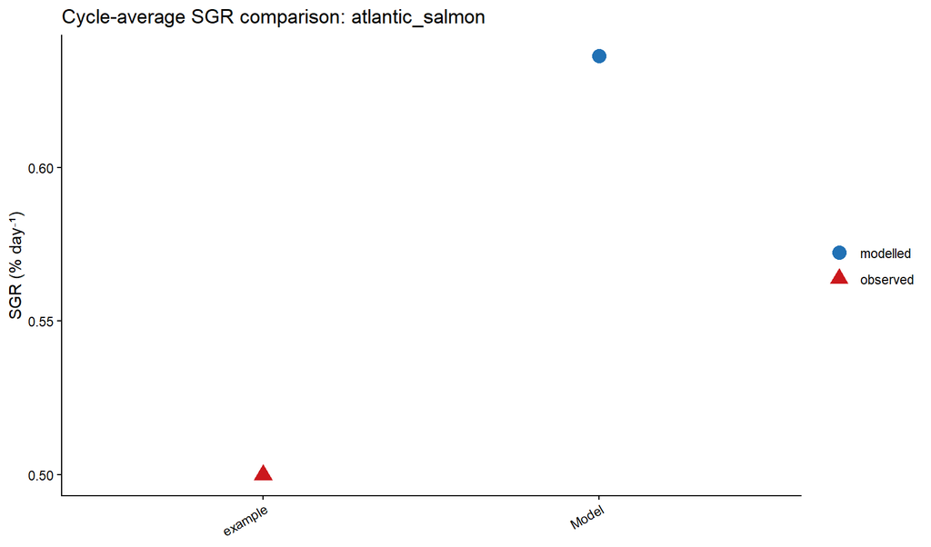

```r
# ── ADD OBSERVED DATA HERE ───────────────────────────────────────────────────
observed_sgr <- tribble(
  ~source,               ~sgr_pct_day,
  "example",             0.5
  # "Author et al. YYYY",  0.0,          # ← replace with real values
)
# ─────────────────────────────────────────────────────────────────────────────

# --- Panel A: cycle-average comparison (if observed data supplied) -----------
if (nrow(observed_sgr) > 0) {
  comparison_sgr <- bind_rows(
    tibble(source = "Model", sgr_pct_day = sgr_avg, type = "modelled"),
    mutate(observed_sgr, type = "observed")
  )

  p_sgr_compare <- comparison_sgr %>%
    ggplot(aes(x = source, y = sgr_pct_day, colour = type, shape = type)) +
    geom_point(size = 4) +
    scale_colour_manual(values = c(modelled = "#2171b5", observed = "#cb181d")) +
    labs(
      x      = NULL,
      y      = "SGR (% day⁻¹)",
      colour = NULL, shape = NULL,
      title  = sprintf("Cycle-average SGR comparison: %s", this_species)
    ) +
    theme_classic() +
    theme(axis.text.x = element_text(angle = 30, hjust = 1))

  print(p_sgr_compare)
} else {
  message("No observed SGR data provided — add rows to `observed_sgr` to enable comparison.")
  cat(sprintf("Cycle-average SGR (model): %.3f %% day⁻¹\n", sgr_avg))
}
```

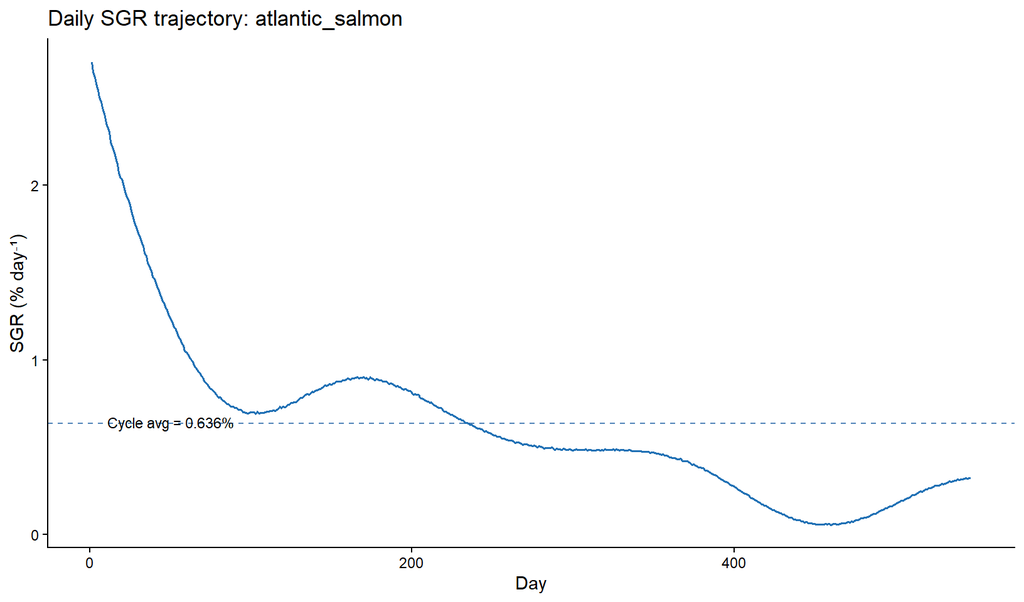

```r
# --- Panel B: daily SGR trajectory ------------------------------------------
tibble(
  day      = one_fish[seq_len(n_days), "days"],
  sgr_daily = sgr_daily
) %>%
  ggplot(aes(day, sgr_daily)) +
  geom_line(colour = "#2171b5", linewidth = 0.6) +
  geom_hline(yintercept = sgr_avg, linetype = "dashed", colour = "#08519c", alpha = 0.7) +
  annotate("text", x = max(one_fish[, "days"]) * 0.02, y = sgr_avg + 0.005,
           label = sprintf("Cycle avg = %.3f%%", sgr_avg), hjust = 0, size = 3) +
  labs(
    x     = "Day",
    y     = "SGR (% day⁻¹)",
    title = sprintf("Daily SGR trajectory: %s", this_species)
  ) +
  theme_classic()
```

← Previous: Choosing species →

Next: TBD →